# BST260 Final Project

Kristyn Beam, Alex Rashedi, and Luis Castelo Branco

12/13/2020

## Examining the Effects of Non-pharmaceutical Interventions (NPIs) on the Incidence of COVID-19 and Other Infectious Diseases in Australia

### Overview and Motivation

COVID-19 has rocked the globe in the year 2020. With its emergence in Wuhan, China in late 2019, high contagiousness, and lack of available medical treatments and interventions, non-pharmaceutical interventions (NPIs) have been the main defense against its spread. Given this fact, investigation into how NPIs have not only affected the spread of COVID-19, but also other infectious diseases transmitted by physical contact or respiratory droplets, is warranted.

Influenza is another infectious disease that is tracked annually and globally, and it has a typical course of increased incidence in the winter (colder) months, virtually disappearing in the summer (warmer) months. COVID-19 emerged in December of 2019 but became particularly prevalent in March of 2020. In the United States (US), “influenza season” is typically November to March, where incidence decreases until the following Fall. Given the non-overlapping seasons for high COVID-19 and influenza incidence in the US, in particular, we decided to conduct the investigation using data from a country in the Southern Hemisphere, instead, where the periods of high incidence would track more closely. Australia was selected for study, as it has a national data collection system for infectious disease incidence as well as national- and regional-level policy institution for COVID-19 management, lending itself well to analyses of the effects of these policy changes on the incidence of COVID-19 and other infectious diseases of interest.

### Related Work

An [article](https://www-nature-com.ezp-prod1.hul.harvard.edu/articles/s41562-020-01009-0) published recently in Nature examined how specific policy changes (i.e., NPIs) have affected the incidence of COVID-19, globally.

“The most effective NPIs include curfews, lockdowns and closing and restricting places where people gather in smaller or large numbers for an extended period of time. This includes small gathering cancellations (closures of shops, restaurants, gatherings of 50 persons or fewer, mandatory home working and so on) and closure of educational institutions.”

We hypothesized that these NPIs have considerable effects on COVID-19 incidence but may also impact the incidences of other infectious diseases, particularly those which similarly spread via physical contact and respiratory droplets.

### Initial Questions

Our questions for this project were whether NPIs instituted to limit the spread of COVID-19 also had an effect on other infectious diseases, with a focus on influenza. There are eight states/territories in Australia: New South Wales, Australian Capital Territory, Queensland, Victoria, Tasmania, Southern Australia, Western Australia, and the Northern Territory. We examined several NPIs discussed in the article cited above, including, but not limited to: Lockdown, Public Awareness, Health Monitoring, Health Resources, Social Distancing, Restriction of Mass Gatherings, and Closure of Schools.

Our initial intention was to investigate how the incidence of COVID-19 and influenza changed over time as new policy restrictions were introduced in each region of Australia. As we further explored our data sources, we found that there were several infectious diseases tracked by Australia, allowing us to look at changes in multiple gastrointestinal (GI), respiratory, and sexually transmitted infections (STIs) of interest using both graphical representations and statistical analyses.

Our plan for statistical analysis was to compare the mean incidence rates of both COVID-19 and influenza over the months prior to the specific NPI implementation to the mean incidence rates over the months after NPI implementation.

### Data

We obtained our data from the following sources:

1. Australian infectious disease data, located [here](https://www1.health.gov.au/internet/main/publishing.nsf/Content/cdnareport.htm).
2. NPI data, located [here](https://www.coronanet-project.org/). This project’s goal is to “…compile a database on government responses to the coronavirus. [The] main focus is to collect as much information as we can about the various fine-grained actions governments are taking to address the effects of the COVID-19 pandemic. To date, this dataset provides the most comprehensive and granular documentation of such government policies in the world, capturing data for 18 broad policy categories alongside many other dimensions, including the initiator, target and timing of a policy.”

We downloaded several of the pre-fabricated .csv files from the listed websites. Given that the CoronaNet Research Project is updated frequently, we used webscraping to download this data in order to utilize the most up-to-date information each time our analysis was updated and/or performed.

We performed numerous data management tasks with the infectious disease data to prepare both count and rate information for analyses, including recoding, filtering, mutating, merging, and transforming. We engaged in similar tasks for the NPI data. Finally, we ensured that all variables across the datasets had the appropriate variable names and type designations for use in our Shiny app.

### Exploratory Analysis

We first generated exploratory line plots of our infectious disease data to look at counts and rates of COVID-19 and other infectious diseases across time based on state/territory to explore initial visualizations.

Lastly, we limited the NPI dataset to only include observations for the first date that each policy type was introduced within each state/territory. Then, we produced a test graph to explore how a vertical line displaying the date for the start of each of these policies visually mapped onto infectious disease incidence within each region.

```r
# Read in weekly influenza count data by Australian region
aus_dat <- read.csv("https://raw.githubusercontent.com/kristynbeam/BST260Project_KB_LC_AR/main/project_data_files/aus_flu_08_17.csv")

aus_dat <- aus_dat %>%
  # Rename variables
  rename(week = Week.Ending..Friday.,
         age_group = Age..group,
         indig = Indigenous.status,
         flu_type = Type.Subtype,
         state = State,
         sex = Sex) %>%
  # Select variables
  select(week,
         state,
         age_group,
         sex,
         indig,
         flu_type)

# Convert variable type
aus_dat$week <- mdy(aus_dat$week)

# View aus_dat
head(aus_dat)
```

```
##         week state age_group    sex         indig      flu_type
## 1 2018-01-05   NSW     00-04 Female not available             B
## 2 2018-01-05   NSW     00-04 Female not available             B
## 3 2018-01-05   NSW     00-04   Male not available A(unsubtyped)
## 4 2018-01-05   NSW     20-24   Male not available             B
## 5 2018-01-05   NSW     25-29   Male not available A(unsubtyped)
## 6 2018-01-05   NSW     30-34 Female not available A(unsubtyped)
```

```r
# Create count data frame using aus_dat
aus_dat_case <- aus_dat %>%
  group_by(week,
           state,
           age_group,
           flu_type, sex) %>%
  summarize(n_cases = n())
```

```r
# Read in Australian infectious disease data
aus_data <- read.csv("../project_data_files/Australian_data_clean.csv")

# Create function to remove NA values
not_all_na <- function(x) any(!is.na(x))

aus_data <- aus_data %>%
  # Remove NA values
  select_if(not_all_na) %>%
  # Rename variable
  rename("Disease" = "X")

# View aus_data
head(aus_data)
```

```
##                        Disease     Date ACT_n NSW_n NT_n Qld_n SA_n Tas_n Vic_n
## 1              Hepatitis (NEC) 10/31/20     0     0    0     0    0     0     0
## 2 Hepatitis B (newly acquired) 10/31/20     0     0    0     2    0     0     1
## 3    Hepatitis B (unspecified) 10/31/20     5   167    2    70   16     1    98
## 4 Hepatitis C (newly acquired) 10/31/20     2     0    0    41    1     0     1
## 5    Hepatitis C (unspecified) 10/31/20    14   223    8   137   14    11   155
## 6                  Hepatitis D 10/31/20     0     5    0     1    0     0     2
##   WA_n Aust_n ACT_rate NSW_rate NT_rate Qld_rate SA_rate Tas_rate Vic_rate
## 1    0      0      0.0        0     0.0      0.0     0.0      0.0      0.0
## 2    0      3      0.0        0     0.0      0.0     0.0      0.0      0.0
## 3   51    410      1.2      2.1     0.8      1.4     0.9      0.2      1.5
## 4    3     48      0.5        0     0.0      0.8     0.1      0.0      0.0
## 5   83    645      3.3      2.8     3.3      2.7     0.8      2.1      2.4
## 6    0      8      0.0      0.1     0.0      0.0     0.0      0.0      0.0
##   WA_rate Aust_rate
## 1     0.0       0.0
## 2     0.0       0.0
## 3     1.9       1.6
## 4     0.1       0.2
## 5     3.2       2.5
## 6     0.0       0.0
```

```r
# Create case data frame and reshape to long format
aus_data_cases <- aus_data %>%
  select("Disease":"Aust_n") %>%
  rename("ACT" = "ACT_n",
         "NSW" = "NSW_n",
         "NT" = "NT_n",
         "Qld" = "Qld_n",
         "SA" = "SA_n",
         "Tas" = "Tas_n",
         "Vic" = "Vic_n",
         "WA" = "WA_n",
         "Australia" = "Aust_n") %>%
  arrange("Date") %>%
  gather(State,
         Cases,
         c("ACT":"Australia"))

# Create rate data frame and reshape to long format
aus_data_rates <- aus_data %>%
  select("Disease"|"Date"|"ACT_rate":"Aust_rate") %>%
  rename("ACT" = "ACT_rate",
         "NSW"="NSW_rate",
         "NT"="NT_rate",
         "Qld"="Qld_rate",
         "SA"="SA_rate",
         "Tas"= "Tas_rate",
         "Vic"="Vic_rate",
         "WA"="WA_rate",
         "Australia"="Aust_rate") %>%
  arrange("Date") %>%
  gather(State,
         Rates,
         c("ACT":"Australia"))

# Join cases and rates data frames
aus_total <- left_join(aus_data_cases,
                       aus_data_rates)

# Convert variable types
aus_total$Date <- mdy(aus_total$Date)
aus_total$Date <- as.Date(aus_total$Date)
aus_total$Cases <- as.numeric(aus_total$Cases)
aus_total$Rates <- as.numeric(aus_total$Rates)

# View aus_total
head(aus_total)
```

```
##                        Disease       Date State Cases Rates
## 1              Hepatitis (NEC) 2020-10-31   ACT     0   0.0
## 2 Hepatitis B (newly acquired) 2020-10-31   ACT     0   0.0
## 3    Hepatitis B (unspecified) 2020-10-31   ACT     5   1.2
## 4 Hepatitis C (newly acquired) 2020-10-31   ACT     2   0.5
## 5    Hepatitis C (unspecified) 2020-10-31   ACT    14   3.3
## 6                  Hepatitis D 2020-10-31   ACT     0   0.0
```

```r
# Rename states/territories
aus_total$State <- recode(aus_total$State,
                          "ACT" = "Australian Capital Territory",
                          "NSW" = "New South Wales",
                          "NT" = "Northern Territory",
                          "Qld" = "Queensland",
                          "SA" = "South Australia",
                          "Tas" = "Tasmania",
                          "Vic" = "Victoria",
                          "WA" = "Western Australia")

# Filter aus_total data frame to only include diseases that have rate > 0.2
aus_total_high <- aus_total %>%
  filter(Rates >= 0.2,
         State != "Australia")

# How many diseases are we left with in this case? n = 42
aus_total_high %>%
  group_by(Disease) %>%
  summarize()
```

```
## # A tibble: 43 x 1
##    Disease
##    <fct>
##  1 Barmah Forest virus infection
##  2 Campylobacteriosis
##  3 Chikungunya virus infection
##  4 Chlamydial infection
##  5 Cholera
##  6 COVID-19
##  7 Cryptosporidiosis
##  8 Dengue virus infection
##  9 Gonococcal infection
## 10 Haemolytic uraemic syndrome (HUS)
## # … with 33 more rows
```

[figure not shown]

```r
# Explore using ggplot
aus_total_high %>%
  ggplot(aes(Date,
             Rates,
             color = Disease)) +
  geom_line()
```

```r
# Save aus_total_high so it can be brought into Shiny app
write.csv(aus_total_high,
          "aus_total_high.csv")

# View aus_total_high
head(aus_total_high)
```

```
##                        Disease       Date                        State Cases
## 1    Hepatitis B (unspecified) 2020-10-31 Australian Capital Territory     5
## 2 Hepatitis C (newly acquired) 2020-10-31 Australian Capital Territory     2
## 3    Hepatitis C (unspecified) 2020-10-31 Australian Capital Territory    14
## 4           Campylobacteriosis 2020-10-31 Australian Capital Territory    91
## 5            Cryptosporidiosis 2020-10-31 Australian Capital Territory     1
## 6                Salmonellosis 2020-10-31 Australian Capital Territory     3
##   Rates
## 1   1.2
## 2   0.5
## 3   3.3
## 4  21.4
## 5   0.2
## 6   0.7
```

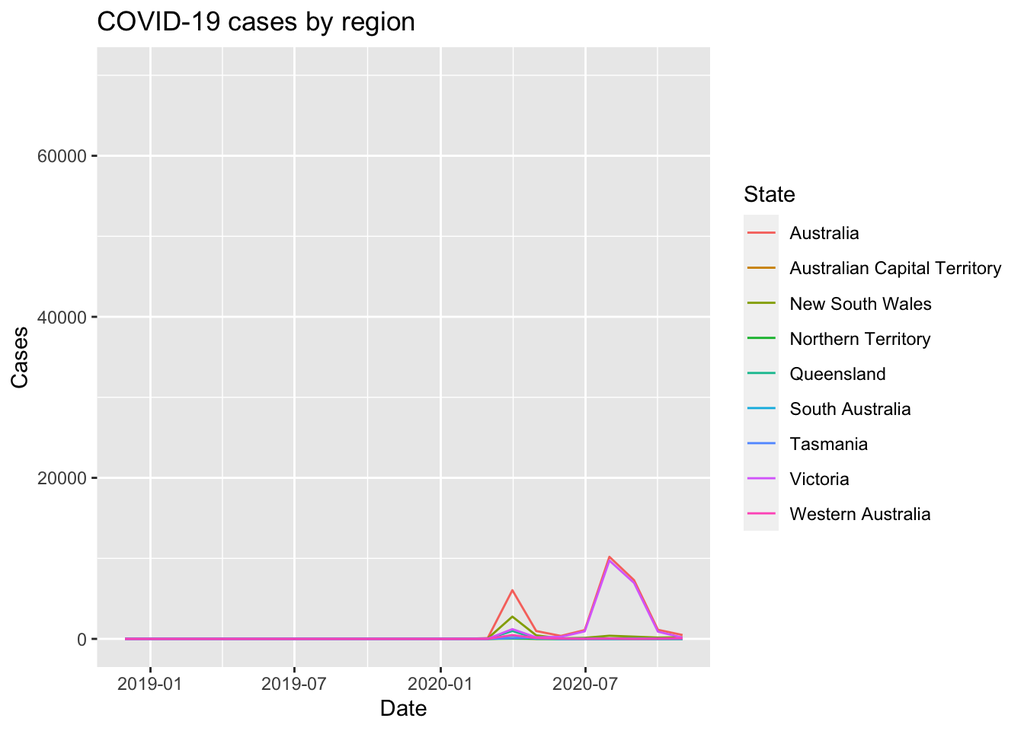

```r
# Create COVID-19 data frame
aus_total_covid <- aus_total %>%
  filter(Disease == "COVID-19")

# Save aus_total_covid so it can be brought into Shiny app
write.csv(aus_total_covid,
          "aus_total_covid.csv")

# Create test COVID-19 plots
p1 <- ggplot(data = aus_total_covid,
            aes(x = Date,
                y = Cases))

p1 + geom_line(aes(color = State)) +
  ggtitle("COVID-19 cases by region") +
  ylim(0, 70000)
```

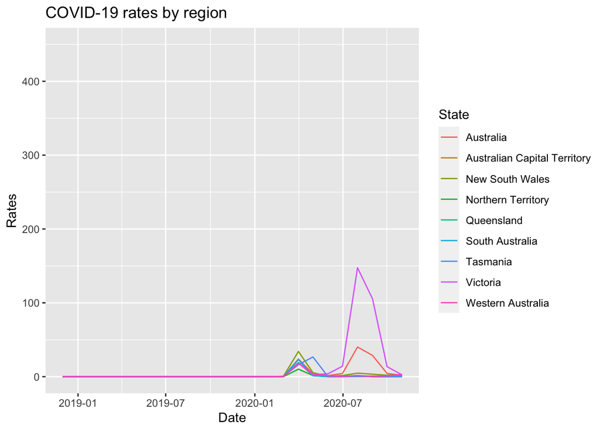

```r
p2 <- ggplot(data = aus_total_covid,
             aes(x = Date,
                 y = Rates))

p2 + geom_line(aes(color = State)) +
  ggtitle("COVID-19 rates by region") +
  ylim(0, 450)
```

```r
# Create influenza data frame (monthly counts and rates by Australian region)
aus_total_influenza <- aus_total %>%
  filter(Disease == "Influenza (laboratory confirmed)")

# Identify earliest date available: 2018-11-30
min(aus_total_influenza$Date)
```

```
## [1] "2018-11-30"
```

```r
# Identify latest date available: 2020-10-31
max(aus_total_influenza$Date)
```

```
## [1] "2020-10-31"
```

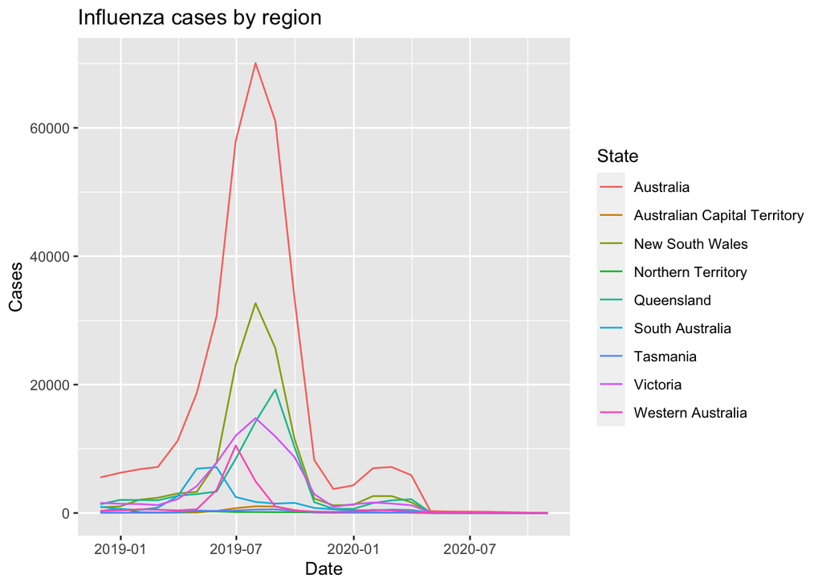

```r
# Create test influenza plots
p3 <- ggplot(data = aus_total_influenza,
             aes(x = Date,
                 y = Cases))

p3 + geom_line(aes(color = State)) +
  ggtitle("Influenza cases by region") +
  ylim(0, 70500)
```

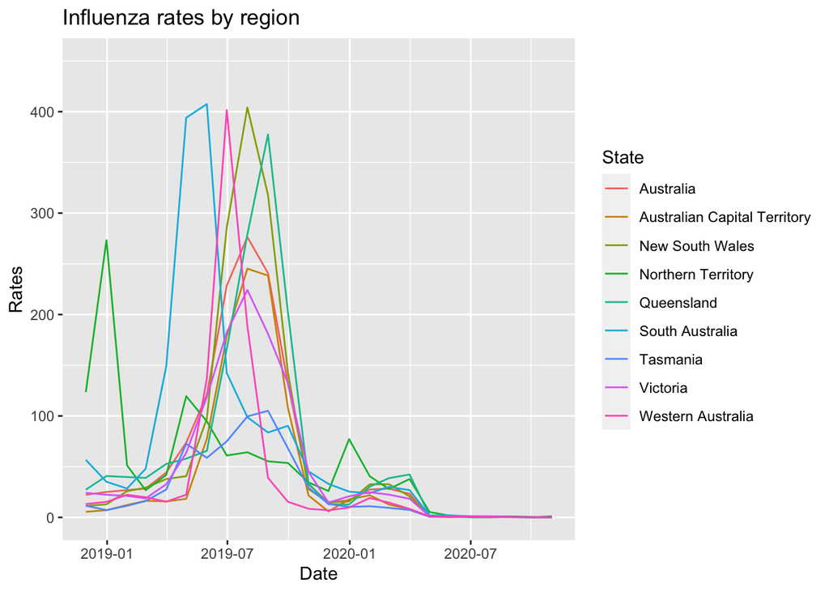

```r
p4 <- ggplot(data = aus_total_influenza,
             aes(x = Date,
                 y = Rates))

p4 + geom_line(aes(color = State)) +
  ggtitle("Influenza rates by region") +
  ylim(0, 450)
```

```r
# Read in Australian policy data by pulling most up-to-date version from Github
pol_dat_aus = read_csv("https://raw.githubusercontent.com/saudiwin/corona_tscs/master/data/CoronaNet/data_country/coronanet_release/coronanet_release_Australia.csv")

pol_dat_aus <- pol_dat_aus %>%
  # Group pol_dat_aus by province and policy type
  group_by(province,
           type) %>%
  # Arrange by date policy goes into effect
  arrange(date_start) %>%
  # Keep only first observation within each province-policy type group
  slice(1) %>%
  # Ungroup
  ungroup() %>%
  # Filter to keep only policies that target Australia
  filter(target_country == "Australia")

# Transform variable types
pol_dat_aus$type <- as.factor(pol_dat_aus$type)
pol_dat_aus$type_sub_cat <- as.factor(pol_dat_aus$type_sub_cat)
pol_dat_aus$target_who_what <- as.factor(pol_dat_aus$target_who_what)

# View pol_dat_aus
head(pol_dat_aus)
```

```
## # A tibble: 6 x 40
##      X1 record_id policy_id entry_type correct_type update_type update_level
##   <dbl> <chr>         <dbl> <chr>      <chr>        <chr>       <chr>
## 1     1 R_33vbEO…   3144269 new_entry  original     <NA>        <NA>
## 2    16 R_32JUZG…   8782298 new_entry  original     <NA>        <NA>
## 3    84 R_Uoxktr…   7561488 new_entry  original     <NA>        <NA>
## 4    88 R_1exbuG…   7065129 new_entry  original     <NA>        <NA>
## 5   108 R_1THehx…   7493721 new_entry  correction   <NA>        <NA>
## 6   198 R_2Brgkm…   4657525 new_entry  original     <NA>        <NA>
## # … with 33 more variables: description <chr>, date_announced <date>,
## #   date_start <date>, date_end <date>, country <chr>, ISO_A3 <chr>,
## #   ISO_A2 <chr>, init_country_level <chr>, domestic_policy <dbl>,
## #   province <chr>, city <lgl>, type <fct>, type_sub_cat <fct>,
## #   type_text <chr>, institution_status <chr>, target_country <chr>,
## #   target_geog_level <chr>, target_region <chr>, target_province <chr>,
## #   target_city <chr>, target_other <lgl>, target_who_what <fct>,
## #   target_direction <chr>, travel_mechanism <chr>, compliance <chr>,
## #   enforcer <chr>, index_high_est <dbl>, index_med_est <dbl>,
## #   index_low_est <dbl>, index_country_rank <dbl>, link <chr>,
## #   date_updated <date>, recorded_date <dttm>
```

```r
list.files()
```

```
## [1] "aus_total_covid.csv"  "aus_total_high.csv"   "data_cleaning_files"
## [4] "data_cleaning.html"   "data_cleaning.Rmd"    "final_proj_file.html"
## [7] "final_proj_file.Rmd"  "pol_dat_aus.csv"
```

```r
# Save pol_dat_aus so it can be brought into Shiny app
write.csv(pol_dat_aus, "pol_dat_aus.csv")
```

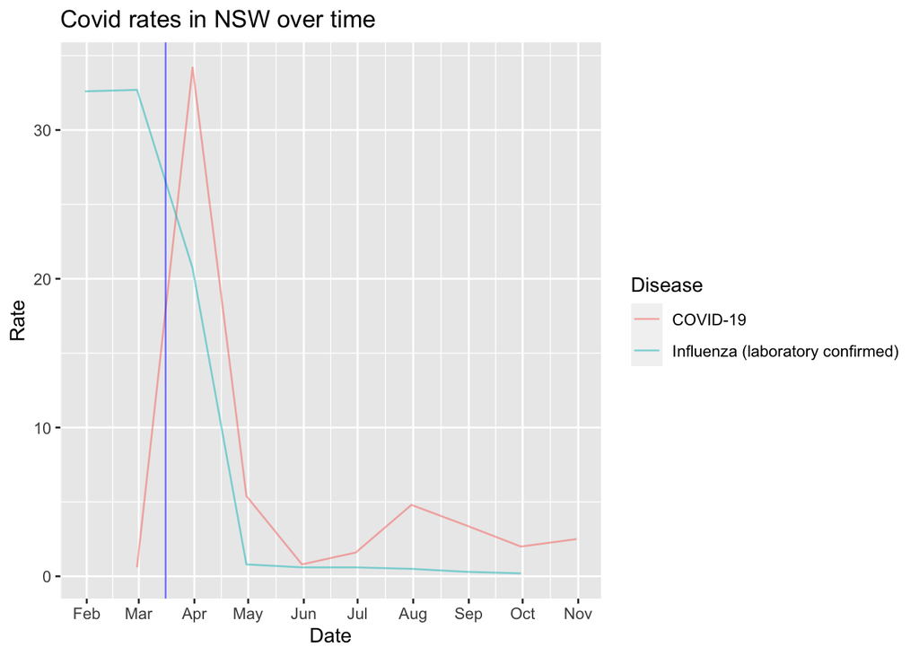

```r
# https://www-nature-com.ezp-prod1.hul.harvard.edu/articles/s41562-020-01009-0
# "The most effective NPIs include curfews, lockdowns and closing and restricting places where people gather in smaller or large numbers for an extended period of time. This includes small gathering cancellations (closures of shops, restaurants, gatherings of 50 persons or fewer, mandatory home working and so on) and closure of educational institutions."

# Test graph
aus_total_high %>%
  filter(State == "New South Wales" & Date >= "2020-01-01" & Disease %in% c("Influenza (laboratory confirmed)",
                                                                            "COVID-19")) %>%
  ggplot(aes(x = Date,
             y = Rates)) +
  geom_line(aes(color = Disease),
            alpha = 0.5) +
  # 2020-03-16 is date of first policy restriction in NSW (restriction of mass gatherings)
  geom_vline(alpha = 0.5,
             xintercept = as.numeric(as.Date("2020-03-16")),
             color = "blue") +
  labs(x = "Date",
       y = "Rate") +
  ggtitle("Covid rates in NSW over time") +
  scale_x_date(date_breaks = "1 month",
               date_labels = "%b")
```

### Final analysis

```r
# Transform variable to date type
aus_total_influenza$Date <- ymd(aus_total_influenza$Date)

# View aus_total_influenza
head(aus_total_influenza)
```

```
##                            Disease       Date                        State
## 1 Influenza (laboratory confirmed) 2020-10-31 Australian Capital Territory
## 2 Influenza (laboratory confirmed) 2020-09-30 Australian Capital Territory
## 3 Influenza (laboratory confirmed) 2020-08-31 Australian Capital Territory
## 4 Influenza (laboratory confirmed) 2020-07-31 Australian Capital Territory
## 5 Influenza (laboratory confirmed) 2020-06-30 Australian Capital Territory
## 6 Influenza (laboratory confirmed) 2020-05-31 Australian Capital Territory
##   Cases Rates
## 1     1   0.2
## 2     1   0.2
## 3     3   0.7
## 4     1   0.2
## 5     3   0.7
## 6     1   0.2
```

```r
# Create a variable: drop in influenza cases from year 1 (Nov/18 to Oct/19) to year 2 (Nov19 to Oct/20)
aus_total_influenza_year1 <- aus_total_influenza %>%
  filter(Date <= "2019-10-31") %>%
  group_by(State) %>%
  summarize(year1 = sum(Cases))

aus_total_influenza_year2 <- aus_total_influenza %>%
  filter(Date > "2019-10-31") %>%
  group_by(State) %>%
  summarize(year2 = sum(Cases))

aus_total_influenza_diff <- left_join(aus_total_influenza_year1,
                                      aus_total_influenza_year2) %>%
  mutate(drop = (year1 - year2) / year1)
```

```r
# Perform web scraping for a dataset that containd the population and population density for the provinces
url <- "https://www.worldatlas.com/articles/which-australian-states-territories-have-the-highest-density-of-population.html"
h <- read_html(url)
density <- h %>%
  html_nodes("table") %>%
  .[1]
density <- density %>%
  html_table %>%
  .[[1]]

density <- density %>%
  rename("State" = "State / Territory") %>%
  rename("density" = "Density (persons per km2)") %>%
  mutate(State = recode(State,
                        "Australian Capital Territory" = "ACT",
                        "New South Wales" = "NSW",
                        "Northern Territory" = "NT",
                        "Queensland" = "Qld",
                        "South Australia" = "SA",
                        "Tasmania" = "Tas",
                        "Victoria" = "Vic",
                        "Western Australia" = "WA"))

density$Population <- as.numeric(gsub(",",
                                      "",
                                      density$Population))

# Join the datasets
aus_total_influenza_diff <- left_join(aus_total_influenza_diff,
                                      density)

# View aus_total_influenza_diff
head(aus_total_influenza_diff)
```

```
## # A tibble: 6 x 8
##   State                  year1 year2  drop  Rank Population `Area (km²)` density
##   <chr>                  <dbl> <dbl> <dbl> <int>      <dbl> <chr>          <dbl>
## 1 Australia             317234 29266 0.908    NA         NA <NA>              NA
## 2 Australian Capital T…   4024   296 0.926    NA         NA <NA>              NA
## 3 New South Wales       115927  9674 0.917    NA         NA <NA>              NA
## 4 Northern Territory      2463   537 0.782    NA         NA <NA>              NA
## 5 Queensland             70262  7318 0.896    NA         NA <NA>              NA
## 6 South Australia        27655  2549 0.908    NA         NA <NA>              NA
```

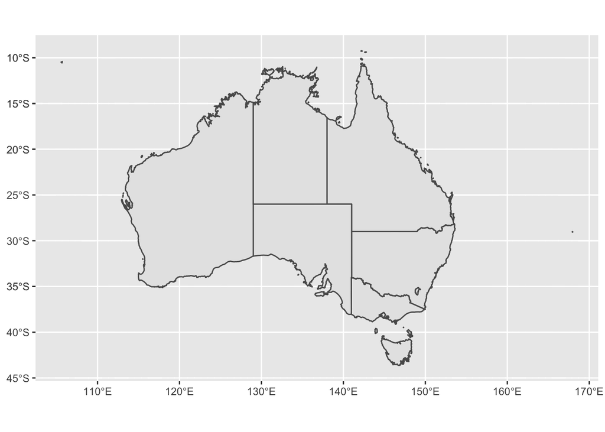

```r
# Create map of Australia
x <- ozmap_data()
ggplot(data = x) +
  geom_sf()
```

```r
# This is an "sf" data structure which can be treated as a df but with an additional column called a geometry. If we want to color the data by Cases or Rates, we would merge this with our df that has the cases and rates information.

# Create a merged dataset of x and aus_total_high
merge_dat <- x %>%
  rename(State = NAME) %>%
  merge(aus_total_high,
        by = "State")
```

##### T-Tests

```r
# Build statistical tests to see if the mean cases of a disease in the first year (without COVID-19) was different from the mean cases in the second year (with COVID-19)

# Example with Influenza
aus_total_influenza_year1 <- aus_total_high %>%
  filter(Disease == "Influenza (laboratory confirmed)") %>%
  filter(Date <= "2019-10-31") %>%
  group_by(State) %>%
  summarize(year1 = mean(Cases))

aus_total_influenza_year2 <- aus_total_high %>%
  filter(Disease == "Influenza (laboratory confirmed)") %>%
  filter(Date > "2019-10-31") %>%
  group_by(State) %>%
  summarize(year2 = mean(Cases))

aus_total_influenza_test <- left_join(aus_total_influenza_year1,
                                      aus_total_influenza_year2) %>%
  filter(State != "Australia")

t.test(aus_total_influenza_test$year1,
       aus_total_influenza_test$year2,
       paired = TRUE,
       alternative = "two.sided")
```

```
##
##  Paired t-test
##
## data:  aus_total_influenza_test$year1 and aus_total_influenza_test$year2
## t = 2.6818, df = 7, p-value = 0.03146
## alternative hypothesis: true difference in means is not equal to 0
## 95 percent confidence interval:
##   350.772 5580.678
## sample estimates:
## mean of the differences
##                2965.725
```

```r
# Example with Gonococcal infection
aus_total_Gono_year1 <- aus_total_high %>%
  filter(Disease == "Gonococcal infection") %>%
  filter(Date <= "2019-10-31") %>%
  group_by(State) %>%
  summarize(year1 = mean(Cases))

aus_total_Gono_year2 <- aus_total_high %>%
  filter(Disease == "Gonococcal infection") %>%
  filter(Date > "2019-10-31") %>%
  group_by(State) %>%
  summarize(year2 = mean(Cases))

aus_total_Gono_test <- left_join(aus_total_Gono_year1,
                                 aus_total_Gono_year2) %>%
  filter(State != "Australia")

t.test(aus_total_Gono_test$year1,
       aus_total_Gono_test$year2,
       paired = TRUE,
       alternative = "two.sided")
```

```
##
##  Paired t-test
##
## data:  aus_total_Gono_test$year1 and aus_total_Gono_test$year2
## t = 1.267, df = 7, p-value = 0.2457
## alternative hypothesis: true difference in means is not equal to 0
## 95 percent confidence interval:
##  -27.74255  91.78421
## sample estimates:
## mean of the differences
##                32.02083
```

```r
# Example with Hepatitis C
aus_total_HepC_year1 <- aus_total_high %>%
  filter(Disease == "Hepatitis C (unspecified)") %>%
  filter(Date <= "2019-10-31") %>%
  group_by(State) %>%
  summarize(year1 = mean(Cases))

aus_total_HepC_year2 <- aus_total_high %>%
  filter(Disease == "Hepatitis C (unspecified)") %>%
  filter(Date > "2019-10-31") %>%
  group_by(State) %>%
  summarize(year2 = mean(Cases))

aus_total_HepC_test <- left_join(aus_total_HepC_year1,
                                 aus_total_HepC_year2) %>%
  filter(State != "Australia")

t.test(aus_total_HepC_test$year1,
       aus_total_HepC_test$year2,
       paired = TRUE,
       alternative = "two.sided")
```

```
##
##  Paired t-test
##
## data:  aus_total_HepC_test$year1 and aus_total_HepC_test$year2
## t = 2.2863, df = 7, p-value = 0.05611
## alternative hypothesis: true difference in means is not equal to 0
## 95 percent confidence interval:
##  -0.350133 20.787633
## sample estimates:
## mean of the differences
##                10.21875
```

```r
# Example with Rotavirus
aus_total_Rota_year1 <- aus_total_high %>%
  filter(Disease == "Rotavirus") %>%
  filter(Date <= "2019-10-31") %>%
  group_by(State) %>%
  summarize(year1 = mean(Cases))

aus_total_Rota_year2 <- aus_total_high %>%
  filter(Disease == "Rotavirus") %>%
  filter(Date > "2019-10-31") %>%
  group_by(State) %>%
  summarize(year2 = mean(Cases))

aus_total_Rota_test <- left_join(aus_total_Rota_year1,
                                 aus_total_Rota_year2) %>%
  filter(State != "Australia")

t.test(aus_total_Rota_test$year1,
       aus_total_Rota_test$year2,
       paired = TRUE,
       alternative = "two.sided")
```

```
##
##  Paired t-test
##
## data:  aus_total_Rota_test$year1 and aus_total_Rota_test$year2
## t = 1.2007, df = 6, p-value = 0.2751
## alternative hypothesis: true difference in means is not equal to 0
## 95 percent confidence interval:
##  -16.74111  49.00302
## sample estimates:
## mean of the differences
##                16.13095
```

```r
# Example with Pertussis
aus_total_Pertussis_year1 <- aus_total_high %>%
  filter(Disease == "Pertussis") %>%
  filter(Date <= "2019-10-31") %>%
  group_by(State) %>%
  summarize(year1 = mean(Cases))

aus_total_Pertussis_year2 <- aus_total_high %>%
  filter(Disease == "Pertussis") %>%
  filter(Date > "2019-10-31") %>%
  group_by(State) %>%
  summarize(year2 = mean(Cases))

aus_total_Pertussis_test <- left_join(aus_total_Pertussis_year1,
                                      aus_total_Pertussis_year2) %>%
  filter(State != "Australia")

t.test(aus_total_Pertussis_test$year1,
       aus_total_Pertussis_test$year2,
       paired = TRUE,
       alternative = "two.sided")
```

```
##
##  Paired t-test
##
## data:  aus_total_Pertussis_test$year1 and aus_total_Pertussis_test$year2
## t = 1.726, df = 7, p-value = 0.128
## alternative hypothesis: true difference in means is not equal to 0
## 95 percent confidence interval:
##  -24.38643 156.20619
## sample estimates:
## mean of the differences
##                65.90988
```

```r
# Example with Chlamydial infection
aus_total_Chlamydia_year1 <- aus_total_high %>%
  filter(Disease == "Chlamydial infection") %>%
  filter(Date <= "2019-10-31") %>%
  group_by(State) %>%
  summarize(year1 = mean(Cases))

aus_total_Chlamydia_year2 <- aus_total_high %>%
  filter(Disease == "Chlamydial infection") %>%
  filter(Date > "2019-10-31") %>%
  group_by(State) %>%
  summarize(year2 = mean(Cases))

aus_total_Chlamydia_test <- left_join(aus_total_Chlamydia_year1,
                                      aus_total_Chlamydia_year2) %>%
  filter(State != "Australia")

t.test(aus_total_Chlamydia_test$year1,
       aus_total_Chlamydia_test$year2,
       paired = TRUE,
       alternative = "two.sided")
```

```
##
##  Paired t-test
##
## data:  aus_total_Chlamydia_test$year1 and aus_total_Chlamydia_test$year2
## t = 1.4087, df = 7, p-value = 0.2018
## alternative hypothesis: true difference in means is not equal to 0
## 95 percent confidence interval:
##  -207.5659  819.3575
## sample estimates:
## mean of the differences
##                305.8958
```

##### Conclusion

Using our Shiny app visualizations, we noted that several NPIs seemed to have an effect on the incidence trajectories of a number of infectious diseases besides COVID-19, including influenza, chlamydia, and pertussis. It did not seem that GI illnesses were greatly affected by NPI implementation.

We performed t-tests to examine the statistical significance of some of these visually noted differences in mean cases of selected infectious diseases from year 1 (2019) to year 2 (2020).

$(\alpha = 0.05)$

Influenza (laboratory confirmed): $p = 0.03$, statistically significant difference in infections between 2019 and 2020

Gonococcal infection: $p = 0.25$; no statistically significant difference in infections between 2019 and 2020

Hepatitis C (unspecified): $p = 0.06$, borderline statistically significant difference in infections between 2019 and 2020

Rotavirus: $p = 0.28$, no statistically significant difference in infections between 2019 and 2020

Pertussis: $p = 0.13$, no statistically significant difference in infections between 2019 and 2020

Chlamydial infection: $p = 0.20$, no statistically significant difference in infections between 2019 and 2020

Though, visually, there appears to be a difference between years 1 and 2 for infection rates of a variety of infectious diseases with the implementation of NPIs, few of these differences are statistically significant (with the exception of influenza and a borderline result for Hepatitis C). As stated previously, in Australia, COVID-19 and influenza are both predicted to be impacted by NPIs which limit human contact due to their common mode of transmission. Some of the other diseases we investigated include GI and blood borne illnesses, which perhaps would not be as impacted by NPI interventions, given that many of the policies we considered are unlikely to greatly alter the human behaviors which would affect transmission of these types of illnesses.

Future studies may examine the (unintended) economic and human health impacts of the implementation of these NPIs in 2020 on the incidence of illnesses other than COVID-19 in Australia and in countries across the globe.